# ZEAL lipids: R/qtl (bcsft) LOD profiles on the UNTRANSFORMED abundance signal

- Show All Code
- Hide All Code
- View Source

Multi-trait glycerolipid QTL overview on the RAW (untransformed) normalized HPLC-MS signal, the scale used by the original High-PC1 QTL analysis (PTxB73_lipid_QTL_GxE): raw species, raw class sums, raw ratios, no log, no count scaling. Haley-Knott interval mapping on the BC2S3 rtiger ancestry mosaic (B73=A / het=H / teosinte=B), marker set + genetic map = the TeoNAM JLM 0.1-cM grid (ZEAL mosaic projected on), taxon covariate, genome-wide 1000-permutation threshold. Candidates = the B73 v5 glycerolipid gene set rebuilt from KEGG zma00561/zma00564 + CornCyc(E2P2) via MaizeMine.

Author

Fausto Rodríguez-Zapata

Published

September 3, 2026

**What this is.** The ZEAL glycerolipid QTL scan run on the **untransformed abundance signal** across all 133 lipid traits (115 species + 10 class sums + 8 ratios). This is the **scale-faithful reproduction** of the original High-PC1 lipid QTL analysis: verified against the original data-prep script (`PTxB73_lipid_QTL_GxE`, the builder of `B73xPT_base_phenotype.csv`), which maps raw species, raw `rowSums` class sums, and raw ratios (`num/den` per plant, then averaged) with **no log and no count scaling**. The only `log10` in that pipeline is on a throwaway matrix used solely to select interesting metabolite ratios via a Gaussian graphical model; it is never a mapped phenotype.

Like the log-scale overview, this reports the traits carrying a **genome-wide significant** QTL, shows their LOD profiles grouped **by lipid class / ratio**, and annotates each significant peak with the glycerolipid **enzyme candidate(s)** whose B73 v5 locus falls inside the QTL support interval.

**ImportantPipeline, map, and genotype, read this first**

- **Scan:** `scripts/zeal_lipid_rqtl_scan.R` with `TAG=raw PHENO_FILE=data/zeal/pheno_lipid_raw.csv` joint `bcsft` (BC₂S₃) Haley-Knott `scanone` over all 133 traits at once, **taxon covariate** (5-family analog), one shared **1000-permutation** genome-wide null. Significance = per-trait 5% permutation LOD threshold.
- **No ZEAL genetic map is estimated**: every cM is a **TeoNAM JLM** distance (9,063-marker 0.1-cM grid); the ZEAL rtiger mosaic is *projected* onto it (nearest block). Markers `S<chr>_<pos_v5>`. Genotypes are HMM-error-corrected before the scan (`calc.genoprob(error.prob=0.01)`).
- **Phenotypes:** per-genotype **normalized MS signal** (peak-area of the ion current, HPLC-MS; single rep, field-position-adjusted values, no replicates), IDs matched to the `nil_id` register (`scripts/zeal_lipid_pheno.R TRANSFORM=none` → `data/zeal/pheno_lipid_raw.csv`). **No transform**: the provided species / class-sum / ratio columns are used as-is (negatives and near-zero below-detection values kept). Sums/ratios are the file’s plant-level-averaged columns, **not** recomputed from the species.
- **Candidates:** `scripts/zeal_lipid_candidates_v5.py` (KEGG→CornCyc/E2P2 via MaizeMine, v5 rebuild); symbols/function from the MaizeGDB curated annotation (`data/Zm00001eb.1.fulldata.txt`). Peak↔︎gene overlap by `TAG=raw` runs of `scripts/zeal_lipid_qtl_annotate.R` / `zeal_lipid_qtl_enzyme_table.py`.

**WarningRaw scale keeps below-detection values: one peak needs care**

On the raw scale the below-detection cells (normalized signal ≤ 0) are kept as near-zero negatives rather than dropped. For **`DGDG_34_6`** (13.7% below-detection) this matters: it shows strong chr3 peaks here (LOD up to 11.5), yet in the log-scale companion run (`na4`) it had **no** significant QTL once below-detection was set to NA, i.e. its signal there was a detection-rate artifact. Read its raw chr3 peaks with that in mind. The other heavy-censoring species (`PC_32_4`, `LPC_18_1`, `PC_32_1`) do **not** produce significant raw peaks. The strong non-censored hits are unaffected.

```r
library(here)
library(data.table)
library(qtl)
library(ggplot2)
library(ggrepel)

RQ <- here("results/sim/zeal/rqtl/lipid")
stopifnot(dir.exists(RQ))
# raw-scale scan: TAG=raw PHENO_FILE=data/zeal/pheno_lipid_raw.csv bash scripts/zeal_lipid_scan_parallel.sh

# joint LOD profile (marker, chr, pos[cM], <133 trait LOD columns>) + per-trait perm threshold
scan <- fread(file.path(RQ, "zeal_lipid_scanone_raw.csv"))
perms <- readRDS(file.path(RQ, "zeal_lipid_perms_raw.rds"))
thr5v <- setNames(as.numeric(summary(perms, alpha = 0.05)), colnames(perms))

summ <- fread(file.path(RQ, "zeal_lipid_qtl_summary_raw.csv"))          # significant QTL (raw)
enz <- fread(file.path(RQ, "zeal_lipid_qtl_enzyme_candidates_raw.csv")) # QTL × enzyme candidate (raw)

# trait -> lipid class + display group (species classes; class sums; ratios)
classify <- function(tr) fifelse(grepl("^[A-Za-z]+_[0-9]+_[0-9]+$", tr), "species",
  fifelse(grepl("^[A-Za-z]+$", tr), "sum", "ratio"))
lipid_class <- function(tr) fifelse(classify(tr) == "ratio", "ratio", sub("_.*$", "", tr))
sig_traits <- sort(unique(summ$trait))
```

## Significant QTL summary (raw scale)

```r
st <- summ[, .(
  trait, class, chr, `peak (Mb)` = round(peak_mb, 1), LOD = round(lod, 1),
  `5% thr` = round(get(if ("thresh" %in% names(summ)) "thresh" else "thr5"), 1),
  `CI (Mb)` = paste0(round(ci_left_mb, 1), "-", round(ci_right_mb, 1)),
  `CI width (Mb)` = round(width_mb, 2), marker
)][order(-LOD)]
knitr::kable(st, caption = sprintf(
  "Genome-wide significant lipid QTL on the UNTRANSFORMED signal (HK scanone, taxon covariate, 1000-perm 5%%): %d peaks across %d traits.",
  nrow(st), uniqueN(summ$trait)
))
```

Genome-wide significant lipid QTL on the UNTRANSFORMED signal (HK scanone, taxon covariate, 1000-perm 5%): 25 peaks across 22 traits.

| trait | class | chr | peak (Mb) | LOD | 5% thr | CI (Mb) | CI width (Mb) | marker |
| --- | --- | --- | --- | --- | --- | --- | --- | --- |
| SQDG_36_5 | species | 2 | 224.1 | 19.9 | 4.5 | 223.9-225.3 | 1.40 | S2_224086481 |
| DGDG_34_6 | species | 3 | 175.5 | 11.5 | 4.8 | 175.1-177.7 | 2.63 | S3_175466706 |
| DGDG_34_6 | species | 3 | 162.7 | 9.9 | 4.8 | 158.2-169.3 | 11.03 | S3_162684686 |
| DGDG_34_6 | species | 3 | 41.3 | 7.1 | 4.8 | 31.5-55 | 23.48 | S3_41318329 |
| LPE_18_2 | species | 6 | 121.7 | 6.8 | 5.3 | 119.9-124.2 | 4.22 | S6_121693247 |
| SQDG_34_1 | species | 2 | 135.9 | 6.7 | 5.7 | 108.9-153.2 | 44.30 | S2_135931354 |
| SQDG_36_2 | species | 1 | 38.1 | 6.6 | 4.5 | 35.8-42.6 | 6.79 | S1_38068683 |
| MGDG_34_6 | species | 3 | 177.3 | 6.4 | 4.5 | 175.1-180.8 | 5.70 | S3_177340148 |
| SQDG_34_4 | species | 1 | 42.7 | 6.2 | 5.1 | 40.4-43.4 | 3.07 | S1_42704574 |
| DGDG_36_4 | species | 3 | 148.6 | 6.2 | 5.0 | 139.7-159.3 | 19.57 | S3_148554507 |
| PE_32_3 | species | 1 | 290.9 | 6.2 | 6.0 | 235.7-291.9 | 56.20 | S1_290858773 |
| PG_36_4 | species | 4 | 8.5 | 6.1 | 5.7 | 8.5-10.8 | 2.32 | S4_8531218 |
| SQDG_34_2 | species | 2 | 223.9 | 5.8 | 4.5 | 223.5-225.6 | 2.08 | S2_223855041 |
| PI | sum | 8 | 10.7 | 5.7 | 5.0 | 9-15.3 | 6.34 | S8_10713216 |
| DGDG_34_0 | species | 2 | 199.0 | 5.7 | 4.7 | 50.5-202.8 | 152.29 | S2_199020644 |
| DGDG_34_0 | species | 2 | 220.0 | 5.6 | 4.7 | 218.5-220.6 | 2.14 | S2_219985855 |
| MGDG_36_4 | species | 3 | 177.7 | 5.5 | 4.5 | 173.5-180.8 | 7.31 | S3_177709437 |
| DGDG_36_6 | species | 10 | 148.7 | 5.5 | 5.4 | 146.9-148.9 | 2.04 | S10_148694661 |
| LPE | sum | 6 | 120.7 | 5.4 | 5.2 | 35.9-124.2 | 88.30 | S6_120709249 |
| DGDG_36_3 | species | 8 | 34.3 | 5.3 | 4.5 | 30.4-81.7 | 51.29 | S8_34282671 |
| DGDG_34_4 | species | 3 | 142.8 | 5.1 | 4.5 | 9.2-177.7 | 168.50 | S3_142771730 |
| MGDG_34_3 | species | 3 | 180.3 | 5.0 | 4.8 | 10.3-180.8 | 170.50 | S3_180301158 |
| MGDG_DGDG | ratio | 8 | 3.8 | 4.9 | 4.5 | 3.1-9 | 5.86 | S8_3803337 |
| MGDG | sum | 3 | 177.3 | 4.7 | 4.4 | 170.1-180.5 | 10.32 | S3_177340148 |
| MGDG_34_4 | species | 3 | 177.3 | 4.7 | 4.4 | 137.1-180.3 | 43.21 | S3_177340148 |

## Enzyme candidates in the QTL intervals

Glycerolipid genes (B73 v5) whose locus falls inside a raw QTL’s LOD-support CI. Symbol + function are the MaizeGDB curated annotation; blank symbol = no curated symbol assigned in v5.

```r
et <- enz[, .(trait, chr, `peak (Mb)` = peak_mb, LOD = lod, `CI (Mb)` = ci_mb,
  `locus (v5)` = locus_id_v5, symbol, `enzyme / function` = enzyme_function)]
knitr::kable(et, caption = sprintf(
  "%d QTL×candidate rows; %d distinct enzymes (%d with a curated symbol).",
  nrow(et), uniqueN(enz$locus_id_v5), uniqueN(enz[symbol != ""]$locus_id_v5)
))
```

178 QTL×candidate rows; 118 distinct enzymes (58 with a curated symbol).

| trait | chr | peak (Mb) | LOD | CI (Mb) | locus (v5) | symbol | enzyme / function |
| --- | --- | --- | --- | --- | --- | --- | --- |
| SQDG_36_5 | 2 | 224.09 | 19.9 | 223.9-225.3 | Zm00001eb111920 |  | Putative methyltransferases-like |
| SQDG_36_5 | 2 | 224.09 | 19.9 | 223.9-225.3 | Zm00001eb111990 | plc3 | phospholipase C |
| DGDG_34_6 | 3 | 41.32 | 7.1 | 31.5-55.0 | Zm00001eb127030 | plc11 | phospholipase C |
| DGDG_34_6 | 3 | 41.32 | 7.1 | 31.5-55.0 | Zm00001eb127520 | gpat5 | glycerol-3-phosphate acyltransferase |
| DGDG_34_6 | 3 | 41.32 | 7.1 | 31.5-55.0 | Zm00001eb128610 |  | 1-phosphatidylinositol 4-kinase |
| LPE_18_2 | 6 | 121.69 | 6.8 | 119.9-124.2 | Zm00001eb279620 |  | Putative 1-phosphatidylinositol-3-phosphate 5-kinase FAB1D |
| SQDG_34_1 | 2 | 135.93 | 6.7 | 108.9-153.2 | Zm00001eb088660 |  | Alpha-galactosidase |
| SQDG_34_1 | 2 | 135.93 | 6.7 | 108.9-153.2 | Zm00001eb089370 |  | Alpha/beta-Hydrolases superfamily protein |
| SQDG_34_1 | 2 | 135.93 | 6.7 | 108.9-153.2 | Zm00001eb091060 | csu50c | NAD kinase 2 chloroplastic |
| SQDG_34_1 | 2 | 135.93 | 6.7 | 108.9-153.2 | Zm00001eb091200 | aldh13 | aldehyde dehydrogenase |
| SQDG_34_1 | 2 | 135.93 | 6.7 | 108.9-153.2 | Zm00001eb093110 |  | Phosphatidylinositol 4-phosphate 5-kinase |
| SQDG_34_1 | 2 | 135.93 | 6.7 | 108.9-153.2 | Zm00001eb093230 |  |  |
| SQDG_36_2 | 1 | 38.07 | 6.6 | 35.8-42.6 | Zm00001eb011350 |  |  |
| SQDG_36_2 | 1 | 38.07 | 6.6 | 35.8-42.6 | Zm00001eb011380 | TIDP3455 | Phospholipase A2-alpha |
| SQDG_36_2 | 1 | 38.07 | 6.6 | 35.8-42.6 | Zm00001eb011460 | mmp66 | Phosphatidylinositol 4-phosphate 5-kinase |
| SQDG_36_2 | 1 | 38.07 | 6.6 | 35.8-42.6 | Zm00001eb011720 | sqd5 | UDP-sulfoquinovose synthase |
| SQDG_36_2 | 1 | 38.07 | 6.6 | 35.8-42.6 | Zm00001eb012010 | dgd4 | digalactosyldiacylglycerol synthase |
| MGDG_34_6 | 3 | 177.34 | 6.4 | 175.1-180.8 | Zm00001eb146170 |  | Serine hydroxymethyltransferase |
| MGDG_34_6 | 3 | 177.34 | 6.4 | 175.1-180.8 | Zm00001eb146180 |  | 1-phosphatidylinositol-3-phosphate 5-kinase |
| MGDG_34_6 | 3 | 177.34 | 6.4 | 175.1-180.8 | Zm00001eb146430 |  | Embryogenesis-associated protein |
| SQDG_34_4 | 1 | 42.70 | 6.2 | 40.4-43.4 | Zm00001eb012980 | pco115659 | CDP-diacylglycerol–glycerol-3-phosphate 3-phosphatidyltransferase 1 |
| PE_32_3 | 1 | 290.86 | 6.2 | 235.7-291.9 | Zm00001eb045860 | pzb01647 | Putative methyltransferase PMT8 |
| PE_32_3 | 1 | 290.86 | 6.2 | 235.7-291.9 | Zm00001eb045960 | si606042h11b | Long-chain-alcohol oxidase |
| PE_32_3 | 1 | 290.86 | 6.2 | 235.7-291.9 | Zm00001eb045990 |  | Long-chain-alcohol oxidase |
| PE_32_3 | 1 | 290.86 | 6.2 | 235.7-291.9 | Zm00001eb047640 | plc10 | phospholipase C |
| PE_32_3 | 1 | 290.86 | 6.2 | 235.7-291.9 | Zm00001eb048150 | gpat7 | glycerol-3-phosphate acyltransferase |
| PE_32_3 | 1 | 290.86 | 6.2 | 235.7-291.9 | Zm00001eb048820 | pap22 | purple acid phosphatase |
| PE_32_3 | 1 | 290.86 | 6.2 | 235.7-291.9 | Zm00001eb050070 | gpx5 | Glycerophosphodiester phosphodiesterase |
| PE_32_3 | 1 | 290.86 | 6.2 | 235.7-291.9 | Zm00001eb050700 |  | Patatin |
| PE_32_3 | 1 | 290.86 | 6.2 | 235.7-291.9 | Zm00001eb050710 |  | Patatin |

[output cut: 148 more lines]

## LOD profiles by lipid class / ratio

Each figure is one lipid class (or the ratios); coloured lines are the class’s traits that carry a significant QTL, across the whole genome (all 10 chromosomes, TeoNAM cM). Dotted lines = each trait’s 5% permutation threshold; red points = significant peaks. **Dashed grey verticals** mark the glycerolipid candidate enzyme loci in the QTL intervals, labelled by `gene_label` (the MaizeGDB symbol, or the assembly locus id `Zm00001eb…` when no symbol is assigned).

```r
# long LOD for significant traits only
lodL <- melt(scan[, c("chr", "pos", sig_traits), with = FALSE],
  id.vars = c("chr", "pos"), variable.name = "trait", value.name = "LOD"
)
lodL[, trait := as.character(trait)][, grp := lipid_class(trait)]

# significant peaks (red points)
pk <- summ[, .(trait, chr, pos = peak_cm, LOD = lod)][, grp := lipid_class(trait)]

# candidate enzyme loci in the QTLs, placed on the TeoNAM cM axis; label = gene_label
nat <- fread(here("data/teonam/teonam_v5_native.tsv"))
bp2cm <- function(ch, bp) {
  n <- nat[chr_v5 == ch & is.finite(cm)][order(pos_v5)]
  if (nrow(n) < 2) NA_real_ else approx(n$pos_v5, n$cm, xout = bp, rule = 2)$y
}
cv5 <- fread(here("data/zeal/lipid_candidates_v5.tsv"))
cv5[, mid := (as.numeric(start) + as.numeric(end)) / 2]
ecand <- unique(enz[, .(locus = locus_id_v5, trait, chr, gene_label)])
ecand[, grp := lipid_class(trait)]
ecand <- merge(ecand, cv5[, .(locus = gene_v5, mid)], by = "locus", all.x = TRUE)
ecand[, cm := mapply(bp2cm, chr, mid)]
cand_grp <- unique(ecand[is.finite(cm), .(grp, chr, cm, gene_label)])

groups <- unique(lodL$grp)
groups <- groups[order(match(groups, c("DGDG", "MGDG", "DG", "PC", "PE", "PG", "PI", "SQDG", "LPC", "LPE", "ratio")))]
```

```r
for (g in groups) {
  d <- lodL[grp == g]
  trs <- sort(unique(d$trait))
  thrg <- data.table(trait = trs, thr = thr5v[trs])
  pkg <- pk[grp == g]
  cl <- cand_grp[grp == g]
  ytop <- max(d$LOD, na.rm = TRUE)
  cat(sprintf("\n\n### %s: %s\n\n", g, paste(trs, collapse = ", ")))
  p <- ggplot(d, aes(pos, LOD, colour = trait)) +
    geom_vline(data = cl, aes(xintercept = cm), inherit.aes = FALSE,
      linetype = "dashed", colour = "grey55", linewidth = 0.3) +
    geom_line(linewidth = 0.5) +
    geom_hline(data = thrg, aes(yintercept = thr, colour = trait),
      linetype = "dotted", linewidth = 0.3, show.legend = FALSE) +
    geom_point(data = pkg, aes(pos, LOD), colour = "red", size = 1.7, inherit.aes = FALSE) +
    ggrepel::geom_text_repel(
      data = cl, aes(x = cm, y = ytop * 1.12, label = gene_label), inherit.aes = FALSE,
      size = 3.5, colour = "grey15", angle = 90, hjust = 0, direction = "x",
      segment.size = 0.2, min.segment.length = 0, max.overlaps = Inf
    ) +
    expand_limits(y = ytop * 1.7) +
    facet_grid(~chr, scales = "free_x", space = "free_x", switch = "x") +
    labs(
      x = "Chromosome (cM, TeoNAM JLM map)", y = "LOD", colour = "trait",
      title = sprintf("ZEAL %s glycerolipid QTL (untransformed signal): HK scanone, taxon covariate, 1000-perm 5%%", g),
      subtitle = "dashed grey = candidate enzyme loci (label = MaizeGDB symbol, else assembly locus id)"
    ) +
    theme_classic(base_size = 12) +
    theme(
      axis.text.x = element_blank(), axis.ticks.x = element_blank(),
      panel.spacing = unit(0.05, "lines"), strip.placement = "outside",
      strip.background = element_blank(), legend.position = "bottom"
    ) +
    scale_x_continuous(expand = c(0.01, 0))
  print(p)
  cat("\n")
}
```

### DGDG: DGDG_34_0, DGDG_34_4, DGDG_34_6, DGDG_36_3, DGDG_36_4, DGDG_36_6

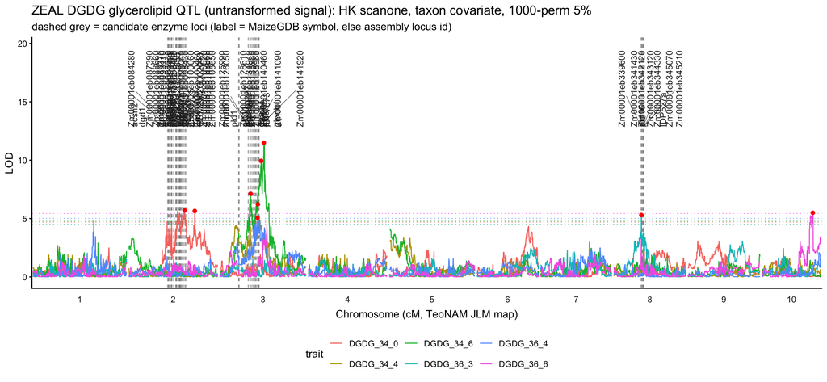

### MGDG: MGDG, MGDG_34_3, MGDG_34_4, MGDG_34_6, MGDG_36_4

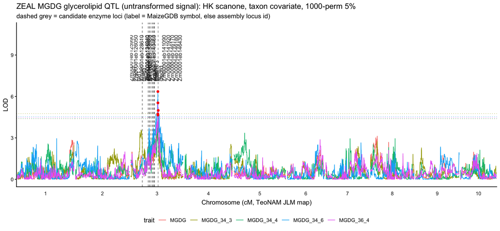

### PE: PE_32_3

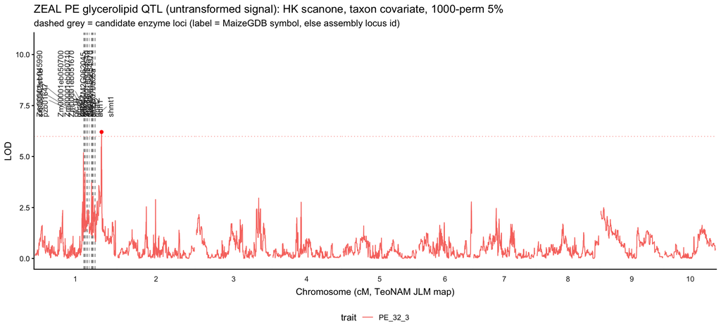

### PG: PG_36_4

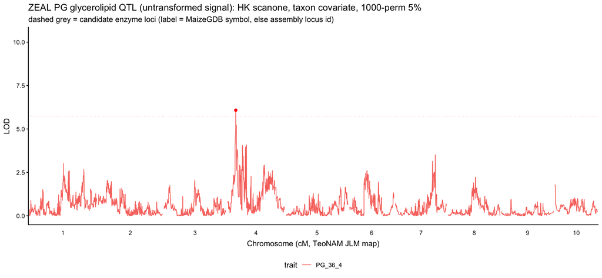

### PI: PI

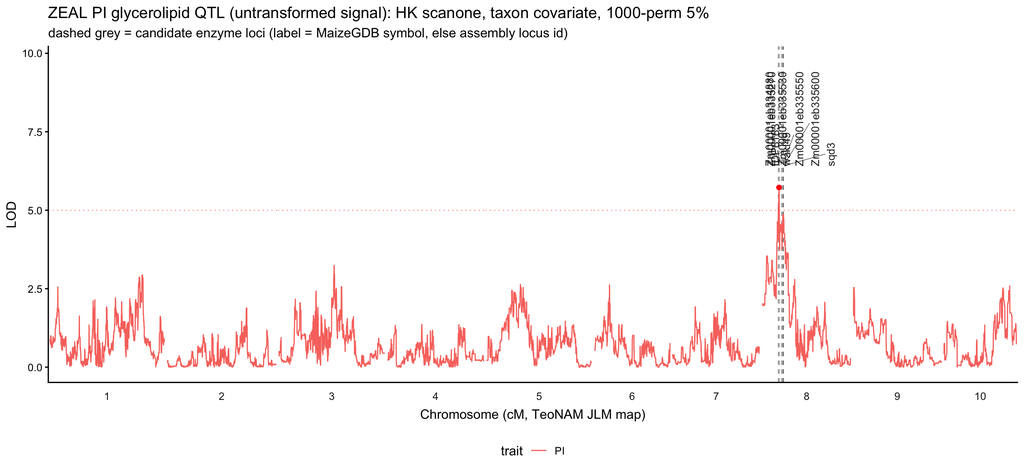

### SQDG: SQDG_34_1, SQDG_34_2, SQDG_34_4, SQDG_36_2, SQDG_36_5

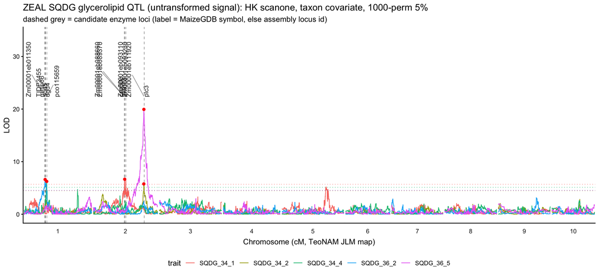

### LPE: LPE, LPE_18_2

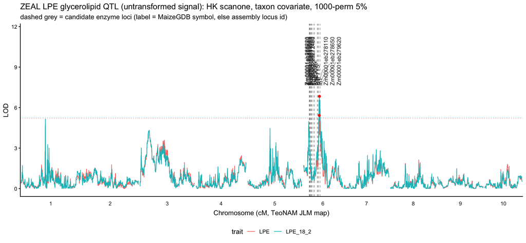

### ratio: MGDG_DGDG

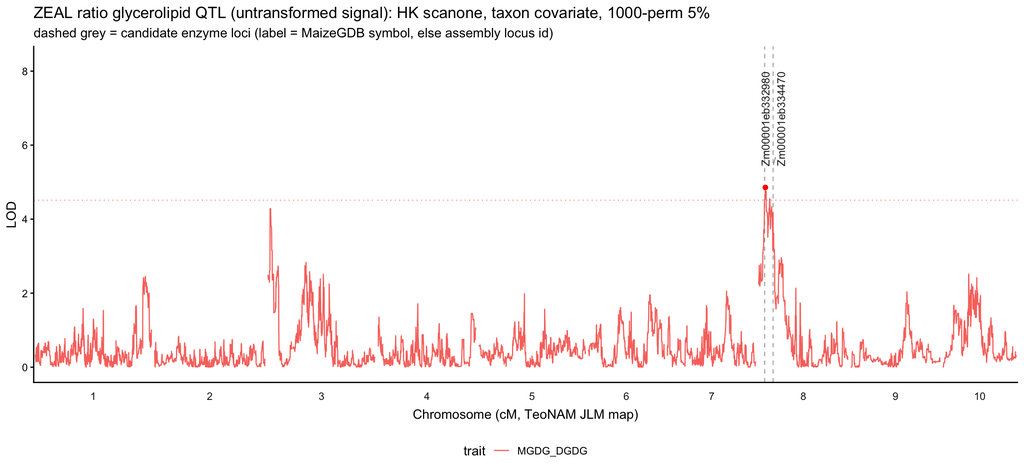

## How the raw-scale result differs from the log-scale scan

This scan is the scale-faithful reproduction; the companion log-scale notebook (`zeal-rqtl-lipid-lod-profile`) uses our own `log10(count+1)` species/sums + `log10(ratio)` variant. Key differences, stated so neither is mistaken for the other:

- **Comparable architecture, not identical:** the raw scan finds 25 significant peaks across 22 traits, close to the log scan’s count, so log-transforming did not create or destroy the bulk of the signal.
- **The `hpc1` chr3 story does NOT reproduce on the raw scale.** In the log run, `hpc1` (Zm00001eb121780, ZmPLA1.2) sat under a chr3 ~8 Mb **LPE**/**LPC_18_1** QTL. On the raw scale **LPE is significant only on chr6 (~120.7 Mb)**, `LPC_18_1` is not significant at all, and **hpc1 falls in no raw QTL CI**. Whether the log-scale chr3 hpc1 peak is a transform-induced effect or the raw scan simply lacks power there is not resolved by this notebook; it is flagged, not explained.
- **`DGDG_34_6` chr3 is strong on raw but was an artifact on log/na4**, see the warning box above.
- **Top raw hit:** `SQDG_36_5` on chr2 (~224 Mb, LOD ~19.9), with `plc3` (phospholipase C) among the candidates in its interval.